# Module 3: Power

What is Power? + Calculating Power.

## Motivation

We haven’t yet answered… How much data should we collect?

## Outcomes of hypothesis testing

|  | $H_0$ is True | $H_0$ is False |
| --- | --- | --- |
| **Reject** $H_0$ | Type I ( ___________) | No Error ( ___________) |
| **Fail to Reject** $H_0$ | No Error ( ___________) | Type II ( ___________) |

## What power means

**Power $(1 - \beta)$**

The **power** of a test is the probability of correctly rejecting the null hypothesis if a particular alternative scenario is true.

$\text{Power} = 1-\beta = P(\text{reject } H_0 \mid \text{a meaningful difference does in fact exist})$

## Why $\beta$ is harder to find than $\alpha$

Power depends on:

- Variability ($\sigma^2$)
- Sample size (replications)
- Design choices

**A key idea:** You cannot compute power for “something differs”

## Example 3.1: Shoe Type (extended)

Suppose, we are preparing to conduct a study for:

- $t = 4$ shoe types
- $r = 3$ runners per shoe
- CRD randomization

## Meaningful difference

$\delta$ = difference worth detecting

- Example: Fastest vs slowest shoe differs by **10 seconds**

## What we must specify

**Information Needed to Calculate the Power of a Test**

1. a specific alternative (e.g., $\delta$)
2. replications per treatment ($r$)
3. variability estimate ($\sigma^2$)
4. significance level ($\alpha$)

## Reminder: the ANOVA test

$$F = \dfrac{\text{MSTrt}}{\text{MSE}}$$

- **If** $H_0$ is true, $F \sim F(\text{df}_1,\text{df}_2)$ (Central $F$)
- **If a specific** $H_A$ is true $F \sim F(\text{df}_1,\text{df}_2,\lambda)$ (Noncentral $F$)

## Degrees of freedom (CRD)

If we have $t$ treatments and $r$ reps each:

- $\text{df}_1 = t - 1$
- $\text{df}_2 = t(r - 1)$

**Example 3.1: Skeleton ANOVA**

| SV | DF: 12 runners - 1 = 11 total |
| --- | --- |
| Shoe Type | (4 - 1) = 3 |
| Runner(Shoe Type) –> error | (3 - 1)(4) = 8 |

## The noncentrality parameter

$$\lambda = \frac{\sum_{i=1}^{t}(\mu_i-\mu)^2}{\sigma^2 / r}$$

- _____ = the mean of the $i^{th}$ treatment group
- _____ = the overall mean
- _____ = the experimental error variance
- _____ = the number of replications of the $i^{th}$ treatment group

**Sanity check**

If all means are equal, then $\lambda = 0$.

## Example 3.1: Shoe Type

Recall, the things we need to calculate power are:

**1. A specific alternative (e.g., $\delta$)**

An ultra-marathon running expert tells us that if there is a difference of 10 seconds between the runners lap times, then that would be of practical importance. Thus, $\delta = 10$.

## Example 3.1: Shoe Type

Recall, the things we need to calculate power are:

**2. Replications per treatment ($r$)**

We are conducting a study with $t = 4$ and $r = 3.$

## Example 3.1: Shoe Type

Recall, the things we need to calculate power are:

**3. variability estimate ($\sigma^2$)**

From an analysis of a pilot study (from Mod 2: CRD Notes), we found $\hat\sigma^2 = 17.46$

**Pilot Studies**

Pilot Studies can be super helpful for estimating experimental error variance $(\hat\sigma^2)$ and differences in group means – key pieces of a power analysis. Running a small version of your experiment gives you data to calculate the mean square error and get a sense of the effect size. This makes it easier to plan the full study and ensure your design has enough power to detect meaningful differences.

## Example 3.1: Shoe Type

Recall, the things we need to calculate power are:

**4. Significance level ($\alpha$)**

We get to set this at $\alpha = 0.05.$

# Power as area

## Power as an area

Consider the central F-distribution with these parameters:

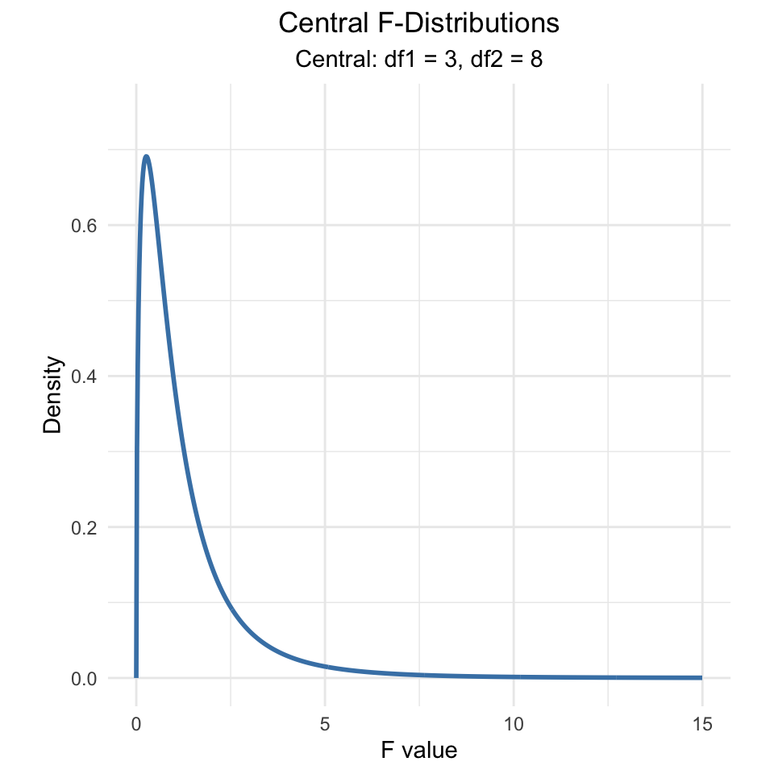

## Power as area

Recall, that the power represents the probability of **rejecting the null** when a specific alternative is true. So let’s focus on the region where we’ll reject the null hypothesis (the Rejection Region)

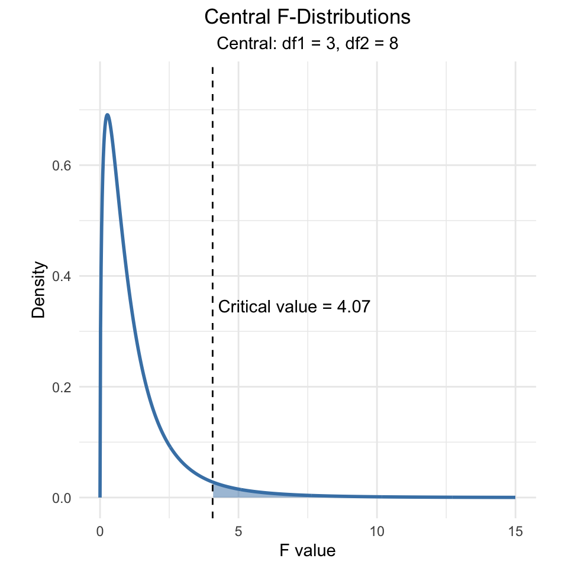

## Power as area

Now, we must incorporate the part about the **specific alternative being true**. If our particular alternative is true, then the F-statistic actually follows a non-central F-distribution with the aforementioned parameters. This is plotted on the same plot as the central F-distribution below here.

**Tip**

Play around with this visualization at [this nifty applet](https://smzr97-test0student-ear.shinyapps.io/power-explorer-323/) that Dr. Robinson made!

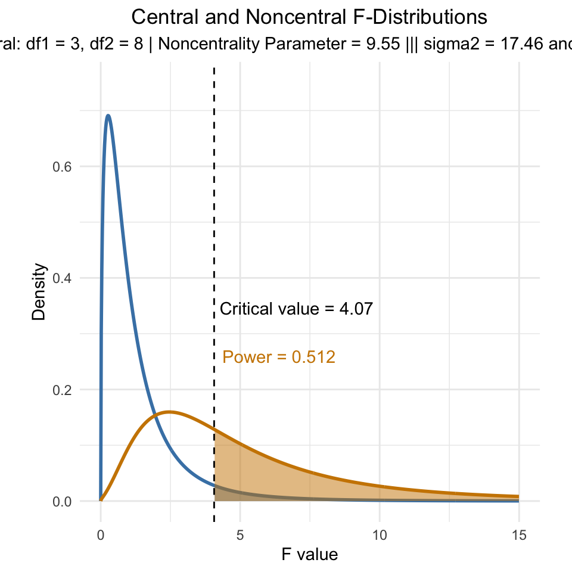

The power for this test is about ________. That is, there is only a 51% chance of correctly rejecting the null hypothesis under these conditions. Do you think this is a good test?

## Ideal Power

For most experiments, we would like the power of the test to be at least __________.

## Power Configurations

Even with the same max difference $\delta$…

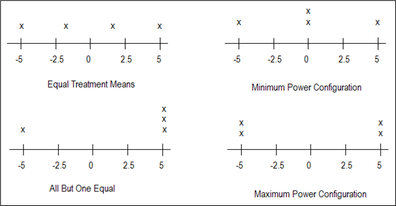

## Power depends on the configuration

| Mean pattern | Power (approx.) |
| --- | --- |
| Maximum power | 0.78 |
| **Minimum power** | **0.47** |
| Equally spaced | 0.51 |
| All but one equal | 0.65 |

## Power in R with `pwr2` package

```r
# Install pwr2 this special way
pak::pak("cran/pwr2")
library(pwr2)
```

What is the the power of my test?

```r
pwr.1way(
  k = 4,              # Number of groups
  n = 3,              # Sample size per group
  alpha = 0.05,       # Significance level
  delta = 10,         # Difference in group means
  sigma = sqrt(17.46) # Standard deviation of obs
)
```

```
     Balanced one-way analysis of variance power calculation

              k = 4
              n = 3
          delta = 10
          sigma = 4.178516
    effect.size = 0.8461218
      sig.level = 0.05
          power = 0.4678701

NOTE: n is number in each group, total sample = 12 power = 0.467870105738621
```

What is the sample size I need?

```r
ss.1way(
  k = 4,               # Number of groups
  alpha = 0.05,        # Significance level
  beta = 1 - 0.80,     # Type II error rate (1 - power)
  delta = 10,          # Difference in group means
  sigma = sqrt(17.46), # Standard deviation of obs
  B = 100              # Number of iterations for numerical search
)
```

```
     Balanced one-way analysis of variance sample size adjustment

              k = 4
      sig.level = 0.05
          power = 0.8
              n = 5

NOTE: n is number in each group, total sample = 20
```